# Twitter Sentiment Classifier and Visualizations

## The implementation of Machine Learning and Neural Networks to classify sentiments.

```python
from IPython.display import Image
from IPython.core.display import HTML
Image(url= "http://www.revasolutions.com/wp-content/uploads/sentiment_analytics_header.jpg", width=1000, height=1000)
```

[figure not shown]

## Steps Involved

- Data Loading and Data Cleaning
- Exploratory Data Vizualization
- Text Pre-processing (NLP)
- Sentiment Classifcation and Prediction- "Positive", "Negative","Neutral"
- Building and Validation of Model for Sentiment Prediction- (Comparison of Algorithms such as KNN, SVC, Random Forest, Decision Tree, Adaboost, GNB etc.)
- Building a RNN LSTM Keras Model for Sentiment Classification

#### Import the required libraries and dependencies

## To install a package in python, use the following line of code

- import pip
- def install(package):
- pip.main(['install', package])
- install('package_name')

```python
# Load the required packages and libraries
import codecs
import pandas as pd
from textblob import TextBlob
import re
import codecs
import matplotlib.pyplot as plt
import seaborn
from wordcloud import WordCloud, STOPWORDS
from sklearn.feature_extraction.text import CountVectorizer, TfidfTransformer
from sklearn.naive_bayes import MultinomialNB
from sklearn.svm import SVC, LinearSVC
from sklearn.metrics import classification_report, f1_score, accuracy_score, confusion_matrix
from sklearn.pipeline import Pipeline
from sklearn.grid_search import GridSearchCV
from sklearn.cross_validation import StratifiedKFold, cross_val_score, train_test_split
from sklearn.tree import DecisionTreeClassifier
from sklearn.learning_curve import learning_curve
%matplotlib inline
```

```python
from matplotlib import pylab
%pylab inline
pylab.rcParams['figure.figsize'] = (15, 9)
```

# Load the dataset

```python
tweet_data = pd.read_json("D://Users/Shivam/tweets_epidem.json", lines=True)
len(tweet_data)
```

```
2888
```

```python
tweet_data.head()
```

|  | _id | followers | geo | text | username |
| --- | --- | --- | --- | --- | --- |
| 0 | {'$oid': '596f92b841f0c40878cec676'} | 219 | None | RT @GrantBrooke: On Cholera: @TwigaFoods will ... | Ph_Marshall |
| 1 | {'$oid': '596f92b941f0c40878cec677'} | 75 | None | Good! Now SAVE THE BEES! https://t.co/x7qMctrlSg | TamaraStormborn |
| 2 | {'$oid': '596f92bb41f0c40878cec678'} | 1961 | None | Jubilee gvt shuts Jacaranda &amp; San Valencia... | H_Ojay254 |
| 3 | {'$oid': '596f92bd41f0c40878cec679'} | 4094 | None | So what?... Does it make less of cholera https... | learnednomad |
| 4 | {'$oid': '596f92c141f0c40878cec67a'} | 14 | None | RT @washingtonpost: Scientists plan to trick Z... | rchaipra12 |

```python
tweet_data.drop(tweet_data.columns[[0, 1, 2, 4]], axis=1, inplace=True)
```

```python
tweet_data.head()
```

|  | text |
| --- | --- |
| 0 | RT @GrantBrooke: On Cholera: @TwigaFoods will ... |
| 1 | Good! Now SAVE THE BEES! https://t.co/x7qMctrlSg |
| 2 | Jubilee gvt shuts Jacaranda &amp; San Valencia... |
| 3 | So what?... Does it make less of cholera https... |
| 4 | RT @washingtonpost: Scientists plan to trick Z... |

```python
tweet_data.columns = ['Text']
```

```python
tweet_data.head()
```

|  | Text |
| --- | --- |
| 0 | RT @GrantBrooke: On Cholera: @TwigaFoods will ... |
| 1 | Good! Now SAVE THE BEES! https://t.co/x7qMctrlSg |
| 2 | Jubilee gvt shuts Jacaranda &amp; San Valencia... |
| 3 | So what?... Does it make less of cholera https... |
| 4 | RT @washingtonpost: Scientists plan to trick Z... |

```python
tweet = tweet_data.Text
```

# Get the Sentiments using the TextBlob

```python
import re
from textblob import TextBlob
```

```python
def clean_tweet(tweet):
        '''
        Utility function to clean tweet text by removing links, special characters
        using simple regex statements.
        '''
        return ' '.join(re.sub("(@[A-Za-z0-9]+)|([^0-9A-Za-z \t])|(\w+:\/\/\S+)", " ", str(tweet)).split())
```

```python
clean_tweet(tweet)
```

```
'0 RT On Cholera will 1 Good Now SAVE THE BEES 2 Jubilee gvt shuts Jacaranda amp San Valencia 3 So what Does it make less of cholera https 4 RT Scientists plan to trick Z 5 This is a 90s Dimension Films premise and I am 6 nIt is stupid on part of Shivsen 7 RT Jacaranda Hotel and San Valencia 8 RT Sc…
```

```python
 def get_tweet_sentiment(tweet):
        '''
        Utility function to classify sentiment of passed tweet
        using textblob's sentiment method
        '''
        # create TextBlob object of passed tweet text
        analysis = TextBlob(clean_tweet(tweet))
        # set sentiment
        if analysis.sentiment.polarity > 0:
            return 'positive'
        elif analysis.sentiment.polarity == 0:
            return 'neutral'
        else:
            return 'negative'
```

```python
from IPython.display import Image
from IPython.core.display import HTML
Image(url= "https://git.gitbook.com/raw/caiomsouza/u-tad-final-project/master/images/social_sentiment_logo.png?token=Y2Fpb21zb3V6YTo5YTllZmJhYi03NDg5LTQ4YTUtYThjMy05MDM2Yjc5ODgyMmM%3D", width=1000, height=1000)
```

# Get the Polarity of the tweets

```python
Polarity = []
for tweet in tweet_data['Text']:
    Polarity.append(get_tweet_sentiment(tweet))
```

```python
tweet = tweet_data['Text']
data_sent = {'Text': tweet, 'Polarity': Polarity}
tweet_data = pd.DataFrame(data=data_sent)
tweet_data
```

|  | Polarity | Text |
| --- | --- | --- |
| 0 | positive | RT @GrantBrooke: On Cholera: @TwigaFoods will ... |
| 1 | positive | Good! Now SAVE THE BEES! https://t.co/x7qMctrlSg |
| 2 | positive | Jubilee gvt shuts Jacaranda &amp; San Valencia... |
| 3 | negative | So what?... Does it make less of cholera https... |
| 4 | neutral | RT @washingtonpost: Scientists plan to trick Z... |
| 5 | neutral | This is a 90s Dimension Films premise and I am... |
| 6 | negative | @dayanandnene\nIt is stupid on part of Shivsen... |
| 7 | negative | RT @Mwirigi: Jacaranda Hotel and San Valencia ... |
| 8 | neutral | RT @washingtonpost: Scientists plan to trick Z... |
| 9 | positive | RT @PeachSkwebu: Also still shook at Jay -Z sa... |
| 10 | neutral | This is literally what they are doing to white... |
| 11 | neutral | RT @ashok_rais: #CholeraNairobi Mike Sonko to ... |
| 12 | neutral | RT @waglenikhil: This is blackmailing. Mumbaik... |
| 13 | neutral | RT @washingtonpost: Scientists plan to trick Z... |
| 14 | neutral | RT @washingtonpost: Scientists plan to trick Z... |
| 15 | neutral | I feel like this is the prequel to the headlin... |
| 16 | neutral | RT @washingtonpost: Scientists plan to trick Z... |
| 17 | neutral | Scientists plan to trick Zika-carrying mosquit... |
| 18 | neutral | Scientists plan to trick Zika-carrying mosquit... |
| 19 | neutral | RT @Trackmann: RT if you have never gotten Cho... |
| 20 | neutral | Scientists plan to trick Zika-carrying mosquit... |
| 21 | neutral | RT @bdgrabinski: This is a 90s Dimension Films... |
| 22 | neutral | RT @bdgrabinski: This is a 90s Dimension Films... |
| 23 | neutral | #Kenya: Two Nairobi hotels shut over cholera c... |
| 24 | neutral | RT @washingtonpost: Scientists plan to trick Z... |
| 25 | neutral | RT @washingtonpost: Scientists plan to trick Z... |
| 26 | neutral | RT @washingtonpost: Scientists plan to trick Z... |
| 27 | neutral | RT @washingtonpost: Scientists plan to trick Z... |
| 28 | positive | Great. Now can we do it again except this time... |
| 29 | neutral | woi, my dear, I feel you. We just have to carr... |
| ... | ... | ... |
| 2858 | positive | RT @Sollohmaingi: @OleItumbi @UKenyatta @steph... |
| 2859 | positive | RT @PMaurerICRC: @ICRC expects cholera cases i... |
| 2860 | neutral | RT @frontlinepbs: Yemen is on the brink of fam... |
| 2861 | neutral | https://t.co/0iL7O7wTU0 (Business Now) #Domain... |
| 2862 | negative | RT @ICRC: Torn apart by war, now ravaged by ch... |
| 2863 | positive | RT @rulajebreal: Saudi war in Yemen has caused... |
| 2864 | negative | RT @ICRC: Torn apart by war, now ravaged by ch... |
| 2865 | negative | RT @ionacraig: By the end of 2017 one in every... |
| 2866 | negative | RT @ICRC: Disturbing news from #Yemen: Cholera... |
| 2867 | negative | #SonkoManifestoLaunch What Kidero did to Nairo... |
| 2868 | negative | RT @NoonArabia: #Yemen #cholera outbreak to sp... |
| 2869 | negative | RT @samueloakford: NEW: Oxfam says Yemen's Cho... |
| 2870 | negative | RT @samueloakford: Estimates are that there wi... |
| 2871 | negative | RT @nfcinereporter: #Yemen...cholera outbreak ... |
| 2872 | positive | RT @nfcinereporter: There are 5,000 new cases ... |
| 2873 | negative | RT @ionacraig: By the end of 2017 one in every... |
| 2874 | positive | RT @midoaaaaa: Yemen's children are being kill... |
| 2875 | negative | RT @raphael_osoro: #SonkoManifestoLaunch What ... |
| 2876 | neutral | RT @AnneWaiguru_: Since suffering Cholera like... |
| 2877 | negative | RT @ICRC: Torn apart by war, now ravaged by ch... |
| 2878 | negative | RT @BenjaminNorton: @SamanthaJPower You are re... |
| 2879 | positive | RT @Colonel_edu: We busy spreading cholera at ... |
| 2880 | neutral | RT @Simran84: The worldâ€™s largest outbreak o... |
| 2881 | negative | RT @raphael_osoro: #SonkoManifestoLaunch What ... |
| 2882 | negative | RT @ICRC: Disturbing news from #Yemen: Cholera... |
| 2883 | positive | RT @midoaaaaa: Cholera is sweeping Yemen with ... |
| 2884 | negative | RT @ionacraig: By the end of 2017 one in every... |
| 2885 | negative | RT @raphael_osoro: #SonkoManifestoLaunch What ... |
| 2886 | negative | RT @raphael_osoro: #SonkoManifestoLaunch What ... |
| 2887 | negative | RT @raphael_osoro: #SonkoManifestoLaunch What ... |

2888 rows × 2 columns

```python
tweet_data.to_csv('D://Users/Shivam/Desktop/israr/PhoneAnalysis_tweets.csv')
```

```
neutral     1425
positive     771
negative     692
Name: Polarity, dtype: int64
```

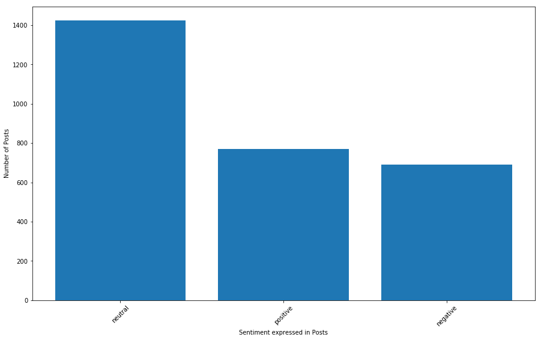

```python
Index = [1,2,3]
print(tweet_data.Polarity.value_counts())
plt.bar(Index,tweet_data.Polarity.value_counts())
plt.xticks(Index,['neutral','positive', 'negative'],rotation=45)
plt.ylabel('Number of Posts')
plt.xlabel('Sentiment expressed in Posts')
```

```python
polar = pd.DataFrame()
n = int(len(tweet))
sen = []
for i in range(n):
    blob = TextBlob(str(tweet[i]))
    k = blob.sentiment.polarity
    sen.append(k)

polar['polarity'] = sen
polar.head()
```

|  | polarity |
| --- | --- |
| 0 | 0.400000 |
| 1 | 1.000000 |
| 2 | 0.200000 |
| 3 | -0.166667 |
| 4 | 0.000000 |

```
array([[<matplotlib.axes._subplots.AxesSubplot object at 0x0000021009431CF8>]], dtype=object)
```

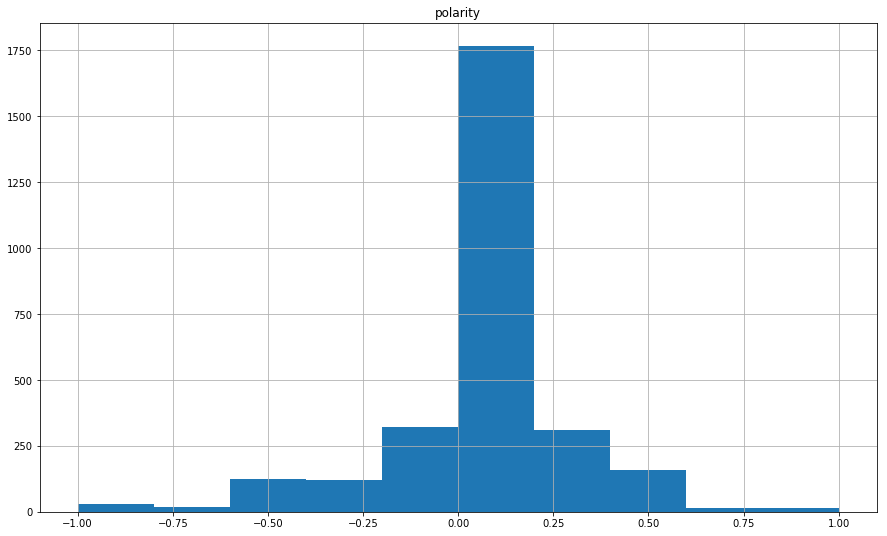

```python
polar.hist()
```

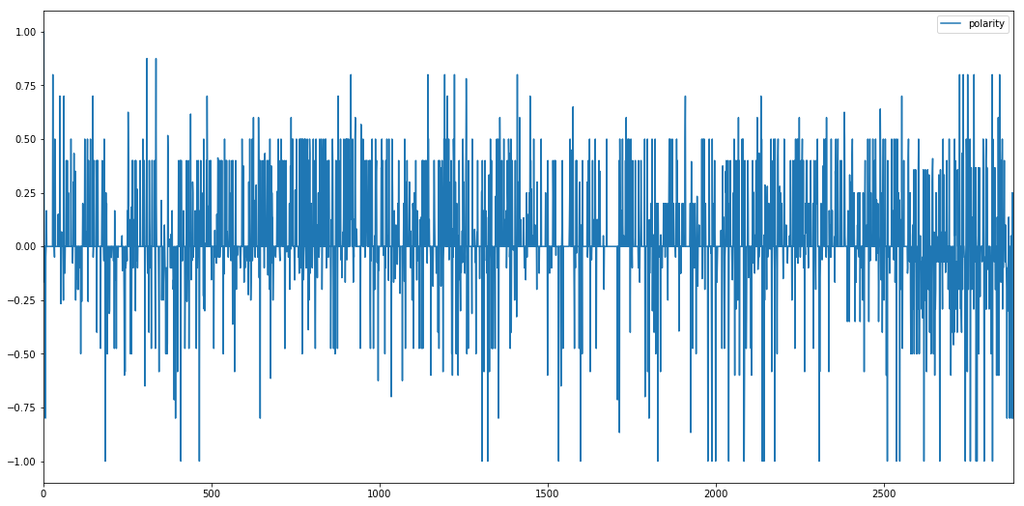

```python
polar.plot.line(x=polar.index,y='polarity',figsize=(18,9))
```

## Is there any difference in tweet length between poitive, negative and neutal?

```python
tweet_data.groupby('Polarity').describe()
```

| Polarity | Text count | Text unique | Text top | Text freq |
| --- | --- | --- | --- | --- |
| negative | 692 | 402 | RT @ICRC: Torn apart by war, now ravaged by ch... | 45 |
| neutral | 1425 | 802 | RT @Waambui: Maybe Health CS Mailu is only clo... | 121 |
| positive | 771 | 352 | RT @GrantBrooke: On Cholera: @TwigaFoods will ... | 140 |

```python
tweet_data['length'] = tweet_data['Text'].map(lambda text: len(text))
tweet_data.head()
```

|  | Polarity | Text | length |
| --- | --- | --- | --- |
| 0 | positive | RT @GrantBrooke: On Cholera: @TwigaFoods will ... | 142 |
| 1 | positive | Good! Now SAVE THE BEES! https://t.co/x7qMctrlSg | 48 |
| 2 | positive | Jubilee gvt shuts Jacaranda &amp; San Valencia... | 142 |
| 3 | negative | So what?... Does it make less of cholera https... | 64 |
| 4 | neutral | RT @washingtonpost: Scientists plan to trick Z... | 135 |

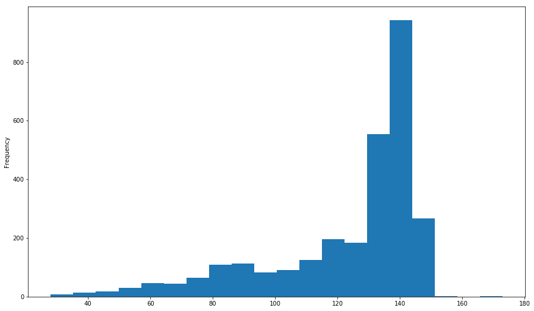

```python
tweet_data.length.plot(bins=20, kind='hist')
```

```
array([[<matplotlib.axes._subplots.AxesSubplot object at 0x000002100984FF60>,
        <matplotlib.axes._subplots.AxesSubplot object at 0x0000021009828D68>]], dtype=object)
```

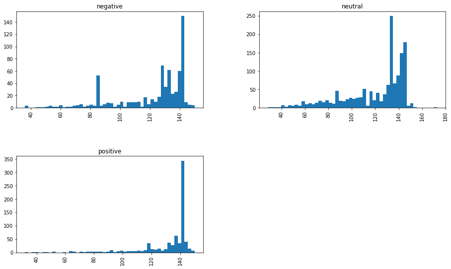

```python
tweet_data.hist(column='length', by='Polarity', bins=50)
```

```python
# Now, get the shape of the dataframe
tweet_data.shape
```

```
(2888, 3)
```

# Pre- processing

```python
## IMPORT REQUIRED LIBRARIES FOR TEXT PRE_PROCESSING
from nltk.tokenize import TweetTokenizer
from nltk.corpus import stopwords
import re, string
import nltk

tweets_texts = tweet_data["Text"].tolist()
stopwords=stopwords.words('english')
english_vocab = set(w.lower() for w in nltk.corpus.words.words())
```

```python
## CREATE A FUNCTION THAT WILL PREPROCESS THE DATA

# For clarity, df is a pandas dataframe with a column['text'] together with other headers.

def tweet_clean(df):
    temp_df = df.copy()
    # Remove hyperlinks
    temp_df.loc[:, "Text"] = temp_df.loc[:, "Text"].replace('https?:\/\/.*\/\w*', '', regex=True)
    # Remove citations
    temp_df.loc[:, "Text"] = temp_df.loc[:, "Text"].replace('\@\w*', '', regex=True)
    # Remove tickers
    temp_df.loc[:, "Text"] = temp_df.loc[:, "Text"].replace('\$\w*', '', regex=True)
    # Remove punctuation
    temp_df.loc[:, "Text"] = temp_df.loc[:, "Text"].replace('[' + string.punctuation + ']+', '', regex=True)
    # Remove quotes
    temp_df.loc[:, "Text"] = temp_df.loc[:, "Text"].replace('\&*[amp]*\;|gt+', '', regex=True)
    # Remove RT
    temp_df.loc[:, "Text"] = temp_df.loc[:, "Text"].replace('RT', '', regex=True)
    # Remove linebreak, tab, return
    temp_df.loc[:, "Text"] = temp_df.loc[:, "Text"].replace('[\n\t\r]+', ' ', regex=True)
    # Remove via with blank
    temp_df.loc[:, "Text"] = temp_df.loc[:, "Text"].replace('via+\s', '', regex=True)
    # Remove multiple whitespace
    temp_df.loc[:, "Text"] = temp_df.loc[:, "Text"].replace('\s+\s+', ' ', regex=True)
    # Remove multiple whitespace
    temp_df.loc[:, "Text"] = temp_df.loc[:, "Text"].replace('\s+\s+', ' ', regex=True)
    # Remove HashTags
    temp_df.loc[:, "Text"] = temp_df.loc[:, "Text"].replace('\#+[\w_]+[\w\'_\-]*[\w_]+', ' ', regex=True)
    # Remove Smileys
    temp_df.loc[:, "Text"] = temp_df.loc[:, "Text"].replace('[:=]+(|o|O| )+[D\)\]]+[\(\[]+[pP]+[doO/\\]+[\(\[]+(\^_\^|)', ' ', regex=True)
    # Remove empty rows
    temp_df = temp_df.dropna()
    return temp_df
```

```python
tweet_clean(tweet_data)
```

|  | Polarity | Text | length |
| --- | --- | --- | --- |
| 0 | positive | On Cholera will be distributing to 2000 mama ... | 142 |
| 1 | positive | Good Now SAVE THE BEES | 48 |
| 2 | positive | Jubilee gvt shuts Jacaranda amp San Valencia h... | 142 |
| 3 | negative | So what Does it make less of cholera | 64 |
| 4 | neutral | Scientists plan to trick Zikacarrying mosquit... | 135 |
| 5 | neutral | This is a 90s Dimension Films premise and I am... | 87 |
| 6 | negative | It is stupid on part of Shivsena to go after ... | 140 |
| 7 | negative | Jacaranda Hotel and San Valencia have been cl... | 141 |
| 8 | neutral | Scientists plan to trick Zikacarrying mosquit... | 135 |
| 9 | positive | Also still shook at Jay Z saying Beyoncé mat... | 142 |
| 10 | neutral | This is literally what they are doing to white... | 78 |
| 11 | neutral | CholeraNairobi Mike Sonko to distribute condo... | 136 |
| 12 | neutral | This is blackmailing Mumbaikar must support | 99 |
| 13 | neutral | Scientists plan to trick Zikacarrying mosquit... | 135 |
| 14 | neutral | Scientists plan to trick Zikacarrying mosquit... | 135 |
| 15 | neutral | I feel like this is the prequel to the headlin... | 103 |
| 16 | neutral | Scientists plan to trick Zikacarrying mosquit... | 135 |
| 17 | neutral | Scientists plan to trick Zikacarrying mosquito... | 115 |
| 18 | neutral | Scientists plan to trick Zikacarrying mosquito... | 115 |
| 19 | neutral | if you have never gotten Cholera from having ... | 133 |
| 20 | neutral | Scientists plan to trick Zikacarrying mosquito... | 115 |
| 21 | neutral | This is a 90s Dimension Films premise and I a... | 104 |
| 22 | neutral | This is a 90s Dimension Films premise and I a... | 104 |
| 23 | neutral | Kenya Two Nairobi hotels shut over cholera con... | 77 |
| 24 | neutral | Scientists plan to trick Zikacarrying mosquit... | 135 |
| 25 | neutral | Scientists plan to trick Zikacarrying mosquit... | 135 |
| 26 | neutral | Scientists plan to trick Zikacarrying mosquit... | 135 |
| 27 | neutral | Scientists plan to trick Zikacarrying mosquit... | 135 |
| 28 | positive | Great Now can we do it again except this time ... | 95 |
| 29 | neutral | woi my dear I feel you We just have to carry f... | 85 |
| ... | ... | ... | ... |
| 2858 | positive | Let him go live from KNH cholera ward so that... | 142 |
| 2859 | positive | expects cholera cases in Yemen to double to 6... | 142 |
| 2860 | neutral | Yemen is on the brink of famine amp dealing w... | 141 |
| 2861 | neutral |  | 85 |
| 2862 | negative | Torn apart by war now ravaged by cholera Toda... | 129 |
| 2863 | positive | Saudi war in Yemen has caused the largest cho... | 138 |
| 2864 | negative | Torn apart by war now ravaged by cholera Toda... | 129 |
| 2865 | negative | By the end of 2017 one in every 45 Yemenis is... | 123 |
| 2866 | negative | Disturbing news from Yemen Cholera cases expe... | 131 |
| 2867 | negative | SonkoManifestoLaunch What Kidero did to Nairob... | 139 |
| 2868 | negative | Yemen cholera outbreak to spread with monsoon... | 117 |
| 2869 | negative | NEW Oxfam says Yemens Cholera outbreak is wor... | 142 |
| 2870 | negative | Estimates are that there will be at least 600... | 142 |
| 2871 | negative | Yemencholera outbreak to spread with monsoon ... | 125 |
| 2872 | positive | There are 5000 new cases of cholera each day ... | 144 |
| 2873 | negative | By the end of 2017 one in every 45 Yemenis is... | 123 |
| 2874 | positive | Yemens children are being killed injured and ... | 144 |
| 2875 | negative | SonkoManifestoLaunch What Kidero did to Nairo... | 142 |
| 2876 | neutral | Since suffering Cholera like symptoms Bae won... | 142 |
| 2877 | negative | Torn apart by war now ravaged by cholera Toda... | 129 |
| 2878 | negative | You are responsible for the worst cholera epi... | 139 |
| 2879 | positive | We busy spreading cholera at the moment stay ... | 122 |
| 2880 | neutral | The world’s largest outbreak of cholera Yemen | 88 |
| 2881 | negative | SonkoManifestoLaunch What Kidero did to Nairo... | 142 |
| 2882 | negative | Disturbing news from Yemen Cholera cases expe... | 131 |
| 2883 | positive | Cholera is sweeping Yemen with more than 3600... | 142 |
| 2884 | negative | By the end of 2017 one in every 45 Yemenis is... | 123 |
| 2885 | negative | SonkoManifestoLaunch What Kidero did to Nairo... | 142 |
| 2886 | negative | SonkoManifestoLaunch What Kidero did to Nairo... | 142 |
| 2887 | negative | SonkoManifestoLaunch What Kidero did to Nairo... | 142 |

2888 rows × 3 columns

## Print the tweets

```python
# let us now, store the text variable of the dataframe in another object
tweets = tweet_data["Text"]
tweets.head(50)
```

```
0     RT @GrantBrooke: On Cholera: @TwigaFoods will ...
1      Good! Now SAVE THE BEES! https://t.co/x7qMctrlSg
2     Jubilee gvt shuts Jacaranda &amp; San Valencia...
3     So what?... Does it make less of cholera https...
4     RT @washingtonpost: Scientists plan to trick Z...
5     This is a 90s Dimension Films premise and I am...
6     @dayanandnene\nIt is stupid on part of Shivsen...
7     RT @Mwirigi: Jacaranda Hotel and San Valencia ...
8     RT @washingtonpost: Scientists plan to trick Z...
9     RT @PeachSkwebu: Also still shook at Jay -Z sa...
10    This is literally what they are doing to white...
11    RT @ashok_rais: #CholeraNairobi Mike Sonko to ...
12    RT @waglenikhil: This is blackmailing. Mumbaik...
13    RT @washingtonpost: Scientists plan to trick Z...
14    RT @washingtonpost: Scientists plan to trick Z...
```

[output cut: 36 more lines]

```python
# Creating a copy of tweets
tweets_copy = tweets
```

# Natural Language Processing

```python
from IPython.display import Image
from IPython.core.display import HTML
Image(url= "https://media.licdn.com/mpr/mpr/AAEAAQAAAAAAAARhAAAAJDk5YjI3YmE1LTRhNWEtNDBjMi1hODE2LTBlNTU3NWU3NzA5Mw.png", width=1000, height=1000)
```

[figure not shown]

```python
# Get all the hashhtag words that has "#"
hashtags = ""
for line in tweets:
    words = line.split()
    for w in words:
        if w.startswith("#"):
            hashtags += w + " "
```

```python
# Print the hashtags
hashtags
```

```
'#CholeraNairobi #Kenya: #Cholera #Kenya #amay #cholera #Kenya #cholera #Yemen, #Kenya #Zika #Corrâ€¦ #Kenya #Yemen #Yemen\'s #Yemen #Anonymous #BreakTheSilenceâ€¦ #cholera #Yemen, #cholera #vaccines #cholera #Yemenâ€™s #Australia #SriLanka #lka #CholeraNairobi #Zika #SANAA, #cholera #vaccines #Zika…
```

### Print the wordcloud

```python
# Get all the hashtags in a list
import re # regular extressions
hashtags_list = re.findall(r"#(\w+)", hashtags)
```

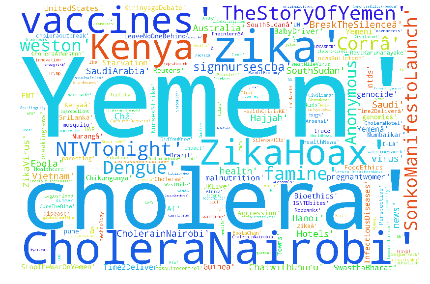

```python
# Set the figure-size
plt.figure(figsize= (20,10))
wordcloud = WordCloud(
                      stopwords=STOPWORDS,
                      background_color='white',
                      width=3000,
                      height=2000
                     ).generate(str(hashtags_list))

plt.figure(1,figsize=(20, 20))
plt.imshow(wordcloud)
plt.axis('off')
plt.savefig('./twitter_wordcloud.png', dpi=300)
plt.show()
```

```python
len(hashtags_list)
```

```
1499
```

## So, this is the preprocessed tweets

```python
# Text contains 'RT' for every retweet and url refrences
# We want to remover 'RT' and URL

filteredTweet = []
def regularExpression(textToFilter):

    retweetPattern = 'RT|@RT'
    urlPattern = 'https://[a-zA-Z0-9+&@#/%?=~_|!:,.;]*'

    for textLine in textToFilter:
        tweet = re.sub(retweetPattern,'',textLine)
        tweet = re.sub(urlPattern,'',tweet)
        filteredTweet.append(tweet)

regularExpression(tweet_data.Text)
```

```python
filteredTweet
```

[output not shown]

[output cut: 946 more lines]

```
 ' @AbdullahiKanuuu: #CholeraNairobi 79 people admitted in different hospital in Nairobi as Sen @MikeSonko is busy distributing condom to fâ€¦',
 ' @KhalidKibet: #CholeraNairobi is gonna get worse while #NursesStrike continues Pay the Nurses. Medical Examination doesnt capture a cholâ€¦',
 ' @HealthRanger: Zika vaccines are nothing more than a money grab.  #zika #vaccines #ZikaHoax',
 '@digby56 Well if you continue cutting the CDC budget then there will be more pre-existing conditions. Better is a jâ€¦ ',
 ' @WHOAFRO: Oral #cholera #vaccines (OCV) are safe, effective &amp; well accepted and are available for individuals aged 1yr &amp; abovâ€¦ ',
 " @GrantBrooke: On Cholera: @TwigaFoods will be distributing to 2,000 mama mbogas and vibandas FREE water sanitation kits. Let's cut the dâ€¦",
 ' @ajplus: There is an army of volunteers in Yemen who go from house-to-house to fight the spread of cholera. ',
 ' @A7medJa7af: "Over 345,000 cholera victim"\nHomage to the children of Yemen\nAcrylic on canvas\nWar on #Yemen\n\nBy Artist Mazher Nizâ€¦ ',
 'Nairobi hotels defy Mailuâ€™s cholera shutdown order ',
 ' @Waambui: Maybe Health CS Mailu is only closing those hotels that have no license to spread cholera. Weston Hotel must be having one. ðŸ˜’#â€¦',
 'Damned Fake Science again! (Sarcasm alert) ',
 ' @blicqer: â–¶@CapitalFMKenya: Two Nairobi hotels shut over cholera concerns ',
 '@MOH_Kenya its such a sorry state in kenya for its citizens dying of cholera. fight for nurses cba as the main body and help save lives.',
 " @kubasubrian: The origin of cholera,Weston can't be touched bcoz the owner has massive political influence..alafu wanafunga hotel I ndogâ€¦",
 ...]
```